Informe de Estadísticas  
Programa Público Inversión Regional (PROPIR) 2025  
Edición 2025

[figure not shown]

Departamento de Estadísticas y Gestión Institucional

Unidad Gestión del Conocimiento y Tecnología

Febrero 2025

## Introducción

El Programa Público de Inversión (PROPIR), detalla la información de los comprometido y aprobado a realizar cada año en las Regiones. En este documento se presentan las estadísticas de los Servicios del Ministerio de Obras Públicas que se están ejecutando o tienen programado a ejecutar durante este año 2025.

Este análisis estadístico tiene como objetivo describir el PROPIR del presente año 2025 para así ver cómo se distribuye la inversión a lo largo del país y sumarlo a los instrumentos de análisis para el proceso de planificación. Este análisis descriptivo se divide en una sección a nivel nacional. Se presentarán tablas y gráficos en cada sección que se visualizan datos relevantes.

## Está dirigido

Este documento está dirigido, en su primera etapa, al equipo de trabajo de la Dirección de Planeamiento (Dirplan), con el objetivo de proporcionar una base de conocimiento sólida sobre la inversión 2025. Para ello, se analizan diversas variables presentes en la base de datos PROPIR 2025 y su relación con factores exógenos, como la pobreza multidimensional, la población registrada en 2017 y la proyección poblacional para 2025. Este análisis busca ofrecer una visión integral de la inversión, permitiendo identificar tendencias y posibles impactos en el desarrollo regional y nacional. Se invita a los miembros de este equipo a revisar el contenido, formular observaciones y sugerencias, y aportar sus conocimientos y experiencias para enriquecer y fortalecer el análisis presentado, de manera que este sea una herramienta analítica que apoye la toma de decisiones estratégicas.

## Metodología

Para obtener los resultados, estadísticas y gráficos, se utilizaron diversas fuentes de información, entre ellas la Planilla de Códigos Únicos Territoriales (CUT), las proyecciones de población para el año 2025, la población censal 2017, los datos de pobreza multidimensional 2022, y los registros del PROPIR 2024 y 2025. La integración de estas bases permitió realizar un análisis detallado de la distribución de población, condiciones socioeconómicas y presencia de inversiones del Ministerio de Obras Públicas (MOP) en distintas comunas del país para el año 2025.

Para la construcción de la base consolidada, en una primera etapa, se unieron las proyecciones de población 2025, la población censal 2017 y los datos de pobreza multidimensional 2022, a través del código único identificador de comunas. Posteriormente, la base del PROPIR 2025 fue complementada con la información de la Planilla CUT, utilizando el nombre de comuna como clave de unión. Este paso permitió incorporar el código único territorial a la base PROPIR 2025, lo que garantizó compatibilidad con el resto de las fuentes de información. Finalmente, se realizó la unión de todas las bases a través del código único identificador de la comuna, generando así la base final utilizada en los análisis.

En primera instancia, se filtra la base por aquellos proyectos que tienen monto asociado mayor que cero. Luego, con el fin de garantizar la consistencia y estandarización de los datos, se realizó un proceso de transformación de la variable correspondiente a cada servicio MOP, por lo que a cada uno de estos se le asignó la abreviación oficial, el procedimiento se encuentra en la “Tabla 0”. Para la construcción de los gráficos y la presentación de la información en formato HTML, se utilizó el software estadístico de código abierto Rstudio, junto a los paquetes especializados en manipulación y visualización de datos.

En la base de datos consolidada, existe una variable llamada ‘Programa’, que indica a cuál programa pertenecen los proyectos. Dada la relevancia del eje ministerial de ‘Seguridad Hídrica’, se exploraron los proyectos nuevos dentro de este eje. Por consiguiente, se filtra la base por proyectos nuevos que pertenezcan al eje de ‘Seguridad Hídrica’. Dentro de este filtro, existían diferentes instancias dentro de la variable ‘Programa’, por lo que fue necesario un tipo de agrupación para visualizar la información de mejor manera, por lo que se crearon cuatro categorías. La primera es ‘Consumo Humano’ que está compuesta por los programas pertenecientes a: agua potable rural semi-concentrada, agua potable rural concentrada, agua potable rural disperso, ampliación y mejoramiento de servicios existentes de agua potable rural y conservación de sistemas sanitarios rurales . La segunda es ‘Riego’ que agrupa: grandes obras de riego, conservación de obras de riego, obras medianas de riego y obras de riego. La categoría ‘Estudios y otros’ reúne los siguientes programas asociados: estudios, Construcción y Reconstrucción. Finalmente, la categoría ‘Gestión’ abarca: redes de medición y análisis y evaluación.

En cuanto a la fórmula de Crec/Decrec relativo de población de 2017 al 2025, se utiliza la siguiente expresión:

$$\text{Crec/Decrec relativo de población 2017 al 2025} =
\left( \frac{\text{Población 2025} - \text{Población 2017}}{\text{Población 2017}} \right) \times 100$$

Tabla 0: Asignación abreviaciones de los Servicios MOP

| Nombre Original del Servicio | Abreviación Asignada |
| --- | --- |
| Dirección de Arquitectura | DA |
| Dirección de Obras Hidráulicas | DOH |
| Dirección de Vialidad | DV |
| Dirección de Obras Portuarias | DOP |
| Dirección de Aeropuertos | DAP |
| Dirección de Planeamiento | DP |
| Subdirección de Servicios Sanitarios Rurales | SSR |
| Conservaciones por Administración Directa - Dirección de Vialidad | DV |
| Conservaciones por Administración Directa - Dirección de Aeropuertos | DAP |
| Dirección General de Concesiones de Obras Públicas | DGC |
| Dirección General de Aguas | DGA |
| Gestión Hídrica y Organizaciones-DGA | DGA |
| Instituto Nacional de Hidráulica | INH |
| Superintendencia de Servicios Sanitarios | SISS |

## Nacional

El análisis de la “Figura 1” muestra que el crecimiento relativo de la inversión PROPIR en 2025 respecto a 2024 es positivo en 13 de las 16 regiones del país. Regiones como Tarapacá (1,73) que representa 1,73 veces la inversión del año 2024, Aysén (1,55), Los Ríos (1,32) y Los Lagos (1,28) presentan los mayores incrementos, mientras que regiones como Atacama, Maule y la región Metropolitana tienen un decrecimiento en comparación a la inversión del año 2024.

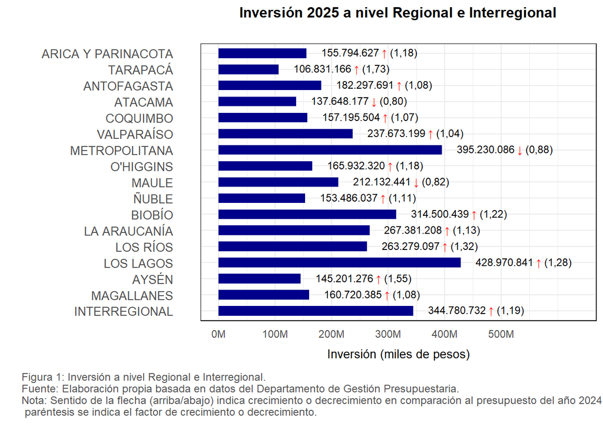

En términos de pobreza multidimensional, la región Metropolitana registra la mayor cantidad de personas en esta condición (1.422.103), seguida de Valparaíso (344.858) y Biobío (237.185), lo que indica desafíos significativos en el acceso a servicios y calidad de vida. Por otro lado, Magallanes y Aysén presentan las cifras más bajas, con 12.472 y 15.113 personas respectivamente.

[output not shown]

Tabla 1: Poblaciones en regiones de Chile. Fuente: Elaboración propia basada en datos del INE, del Departamento de Gestión Presupuestaria y CASEN 2022. (*) Población proyectada al 2025 según el INE. (**) Indica la cantidad de personas en situación de pobreza multidimensional para el año 2022. Nota: Los montos de inversión presentados no incluyen la participación de las regiones en proyectos de carácter interregional.

A través de la Figura 2, se observa que la inversión proyectada para 2025 es, en general, mayor en los proyectos nuevos en comparación con los proyectos de arrastre. Esta tendencia se presenta en los proyectos interregionales y en once regiones del país. Sin embargo, en cinco regiones —Tarapacá, Valparaíso, Maule, La Araucanía y Magallanes— la inversión destinada a proyectos de arrastre supera a la de los nuevos, lo que sugiere una mayor priorización de la continuidad y finalización de iniciativas previamente comenzadas en estas regiones.

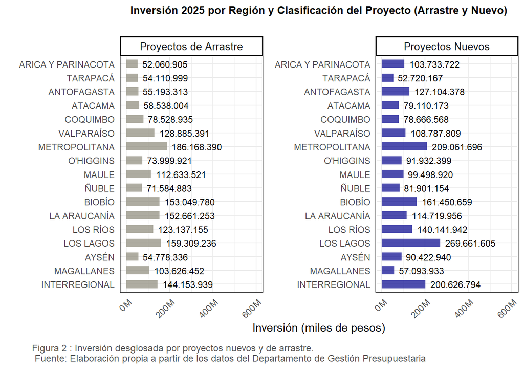

La “Figura 3” muestra que el Eje Ministerial con mayor inversión a nivel nacional es ‘Integración territorial, conectividad y movilidad’, representa el 35% en proyectos de arrastre y el 41,2% en proyectos nuevos, lo que equivale al 76,2% de la inversión total. Esto refleja una fuerte priorización en infraestructura y conectividad a nivel nacional.

Por otro lado, el eje de Seguridad Hídrica presenta una mayor inversión en proyectos nuevos (6,5%) en comparación con los proyectos de arrastre (5,9%), lo que sugiere un enfoque en el desarrollo de nuevas infraestructuras y sistemas de gestión del recurso hídrico. En la misma línea, el eje de ‘Seguridad Ciudadana y ante desastres naturales y emergencias’ también recibe un mayor porcentaje de inversión en proyectos nuevos (4.4%). Sin embargo, a diferencia de los ejes anteriores, el eje de ‘Desarrollo Productivo, Social, Cultural y Científico’ muestra una tendencia inversa, con una mayor inversión en proyectos de arrastre (3,1%) en comparación con proyectos nuevos (1,8%).

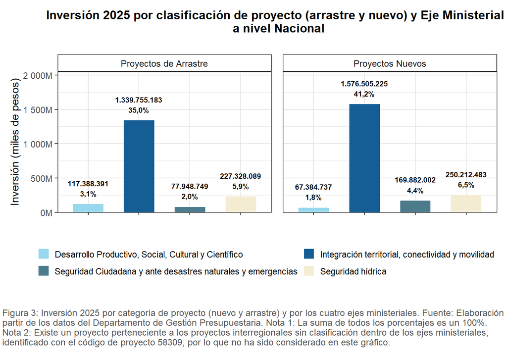

La “Figura 4” muestra la distribución de la inversión 2025 para los servicios asociados al Ministerio de Obras Públicas (MOP) a nivel nacional. Se observa que la mayor inversión se destina a Dirección de Vialidad (DV), con un monto de 2.191.526.451 miles de pesos, lo que representa 57,2% del total.

En segundo lugar, el servicio DGC recibe una inversión de 649.835.693 (miles de pesos), seguido por SSR, con 329.603.442 (miles de pesos), y DOH, con 308.121.429 (miles de pesos). Dentro de la categoría “Otros”, se destaca que el servicio DA recibe la mayor inversión con 1,491%, seguido por DGA (0,592%). Los servicios DP, INH y SISS tienen una inversión significativamente menor, y cada uno representa menos del 0.1%.

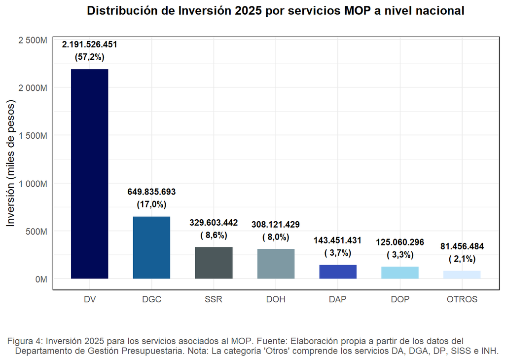

| Servicio | Inversión | Porcentaje (%) |
| --- | --- | --- |
| DA | 57.091.817 | 1,491 |
| DGA | 22.676.579 | 0,592 |
| DP | 1.272.013 | 0,033 |
| INH | 178.841 | 0,005 |
| SISS | 237.234 | 0,006 |

Tabla 2: Servicios agrupados en ‘Otros’, los cuáles incluyen DA, DGA, DP, SISS e INH. Fuente: tabla construida a partir de los datos del Departamento de Gestión Presupuestaria

En la Figura 5, se muestra la distribución de la inversión de proyectos categorizados como nuevos pertenecientes al eje de Seguridad Hídrica, se puede notar una clara prioridad en el abastecimiento de agua potable y riego. Gran parte del porcentaje de la inversión es asignado a ‘Consumo Humano’ (47,23%) y ‘Riego’ (43,7%). En contraste, la inversión en ‘Estudios y Otros’ (6,78%) y en ‘Gestión’ (2,29%) es significativamente menor.

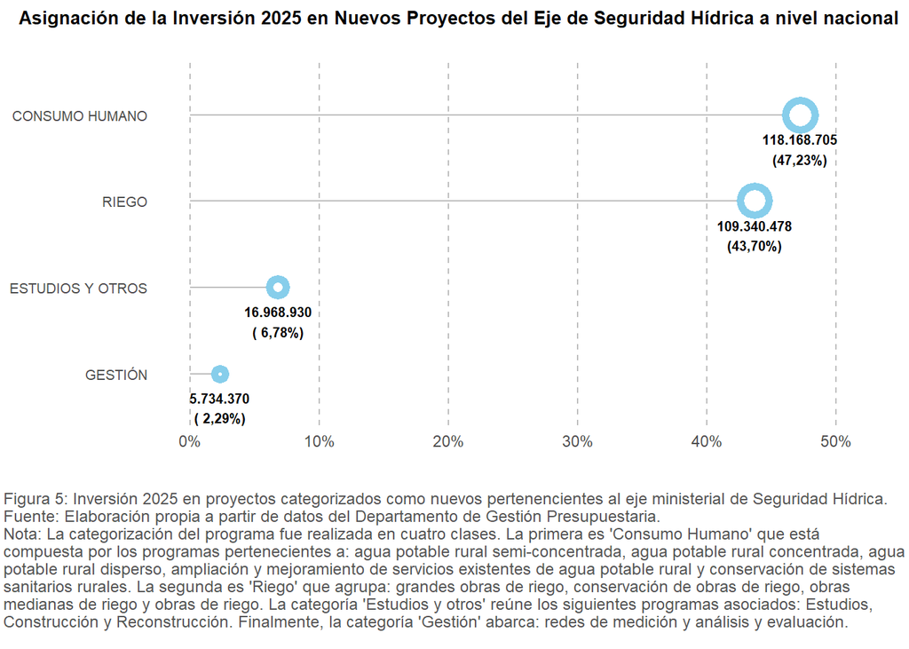

## Fuentes

1. Número de regiones, provincias y comunas fueron recuperados de: Planilla Códigos Únicos Territoriales (CUT), 2018. Subsecretaría de Desarrollo Regional y Administrativo (SUBDERE). Recuperado a partir de: https://www.subdere.gov.cl/documentacion/c%C3%B3digos-%C3%BAnicos-territoriales-actualizados-al-06-de-septiembre-2018
2. Proyección de población, INE. Recuperado a partir de: https://www.ine.gob.cl//estadisticas/sociales/demografia-y-vitales/proyecciones-de-poblacion
3. Estimación de pobreza, casen 2022. Recuperado a partir de: https://observatorio.ministeriodesarrollosocial.gob.cl/pobreza-comunal-2022
4. Propir de los años 2024 y 2025. Recuperado a partir del Departamento de Gestión Presupuestaria
5. Censo 2017, INE. Recuperado a partir de: https://www.ine.gob.cl/estadisticas/sociales/censos-de-poblacion-y-vivienda/censo-de-poblacion-y-vivienda